# Create your own application

Now that you've explored and enhanced the sample project created by the wizard, you can create your own application from scratch, using concepts you already know and introducing some new ones.

You'll create a "Local time application" where users can enter their country and city, and the app will display the time in the capital city of that country. All the functionality of your Compose Multiplatform app will be implemented in common code using multiplatform libraries. It'll load and display images within a dropdown menu and will use events, styles, themes, modifiers, and layouts.

## Lay the foundation

To get started, implement a new `App()` composable:

1. In `shared/src/commonMain/kotlin`, open the `App.kt` file and replace the code with the following `App()` composable:

   ```
   @Composable
   @Preview
   fun App() {
       MaterialTheme {
           var timeAtLocation by remember { mutableStateOf("No location selected") }

           Column(
               modifier = Modifier
                   .safeContentPadding()
                   .fillMaxSize(),
           ) {
               Text(timeAtLocation)
               Button(onClick = { timeAtLocation = "13:30" }) {
                   Text("Show Time At Location")
               }
           }
       }
   }
   ```

   - The layout is a column containing two composables. The first is a `Text` composable, and the second is a `Button`.
   - The two composables are linked by a single shared state, namely the `timeAtLocation` property. The `Text` composable is an observer of this state.
   - The `Button` composable changes the state using the `onClick` event handler.
2. Run the application on Android and iOS:

[figure not shown]

   When you run your application and click the button, the hardcoded time, 13:30, is displayed.
3. Run the application on the desktop using Compose Hot Reload by starting the "🔥desktopApp" run configuration. The app works, but the window looks mismatched with the UI:

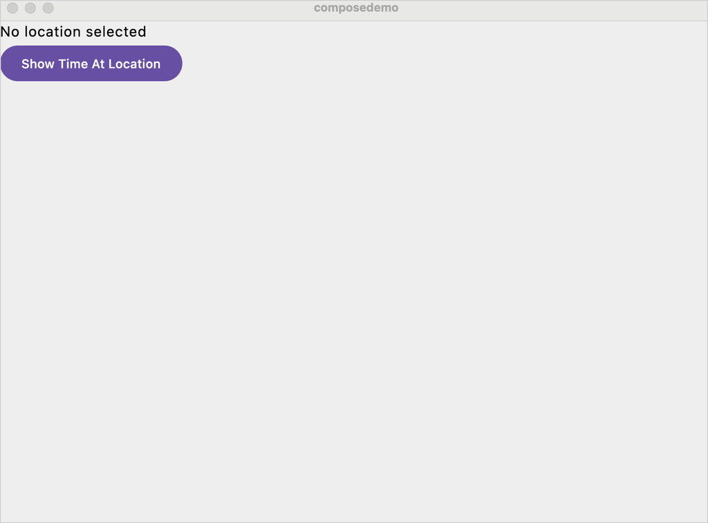

4. To fix this, update the `main.kt` file in the `desktopApp` source set as follows:

   ```
   fun main() = application {
       val state = rememberWindowState(
           size = DpSize(400.dp, 350.dp),
           position = WindowPosition(300.dp, 300.dp)
       )
       Window(
           title = "Local Time App",
           onCloseRequest = ::exitApplication,
           state = state,
           alwaysOnTop = true
       ) {
           App()
       }
   }
   ```

   Here, you set the title of the window and use the `WindowState` type to give the window an initial size and position on the screen.
5. Follow the IDE's instructions to import the missing dependencies.
6. To see the app automatically update, save any modified files (`⌘ S`/`Ctrl+S`). Its appearance should improve:

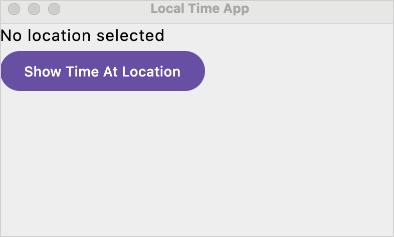

[figure not shown]

## Support user input

Now let users enter the name of a city to see the time at that location. The simplest way to achieve this is by adding a `TextField` composable:

1. Replace the current implementation of `App()` in `commonMain/kotlin/compose.project.demo/App.kt` with the one below:

   ```
   @Composable
   @Preview
   fun App() {
       MaterialTheme {
           var location by remember { mutableStateOf("Europe/Paris") }
           var timeAtLocation by remember { mutableStateOf("No location selected") }

           Column(
               modifier = Modifier
                   .safeContentPadding()
                   .fillMaxSize(),
           ) {
               Text(timeAtLocation)
               TextField(value = location, onValueChange = { location = it })
               Button(onClick = { timeAtLocation = "13:30" }) {
                   Text("Show Time At Location")
               }
           }
       }
   }
   ```

   The new code adds both the `TextField` and a `location` property. As the user types into the text field, the value of the property is incrementally updated using the `onValueChange` event handler.
2. Follow the IDE's suggestions to import the missing dependencies.
3. Run the application on each platform you're targeting. The time displayed is still hardcoded, but now you can enter a timezone in the text field:

[figure not shown]

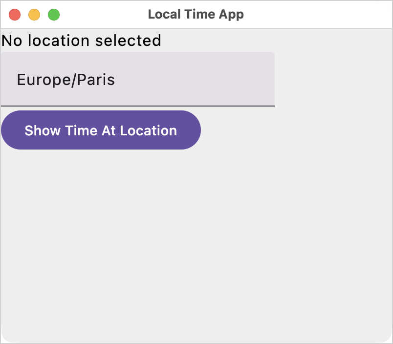

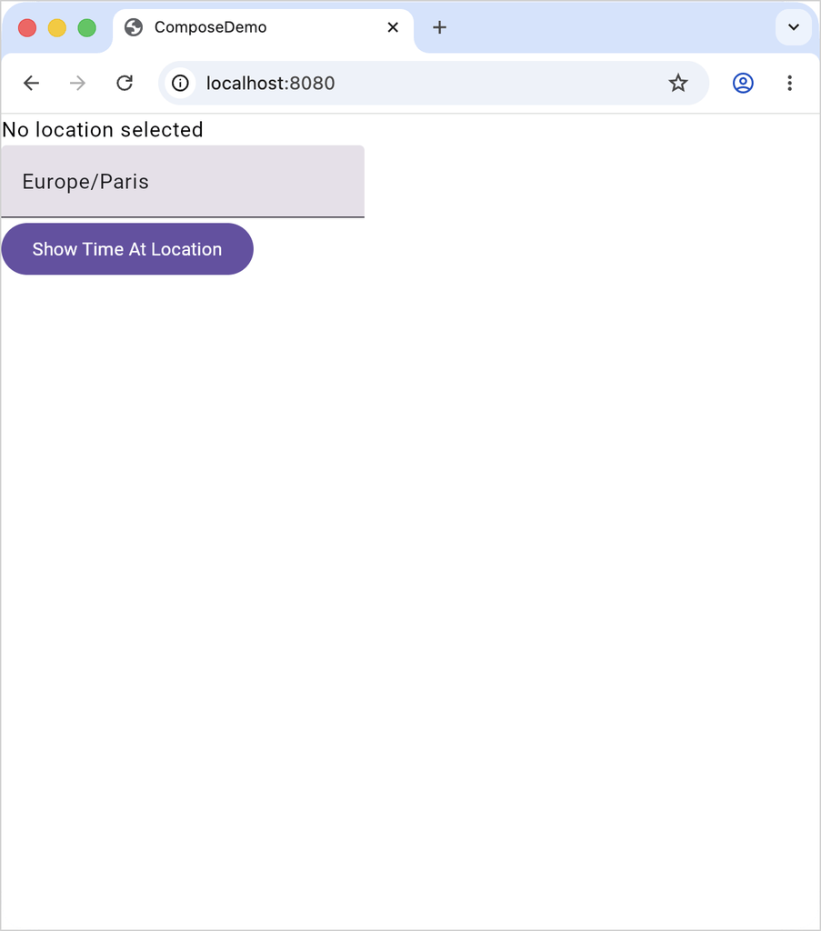

## Calculate time

The next step is to use the given input to calculate time. To do this, create a `currentTimeAt()` function:

1. Return to the `shared/src/commonMain/kotlin/compose.project.demo/App.kt` file and add the following function:

   ```
   fun currentTimeAt(location: String): String? {
       fun LocalTime.formatted() = "$hour:$minute:$second"

       return try {
           val time = Clock.System.now()
           val zone = TimeZone.of(location)
           val localTime = time.toLocalDateTime(zone).time
           "The time in $location is ${localTime.formatted()}"
       } catch (ex: IllegalTimeZoneException) {
           null
       }
   }
   ```

   This function is similar to `todaysDate()`, which you created earlier and which is no longer required.
2. Follow the IDE's instructions to import the missing dependencies. Make sure to import the `Clock` class from `kotlin.time`, not `kotlinx.datetime`.
3. Adjust your `App` composable to invoke `currentTimeAt()`:

   ```
   @Composable
   @Preview
   fun App() {
   MaterialTheme {
      var location by remember { mutableStateOf("Europe/Paris") }
      var timeAtLocation by remember { mutableStateOf("No location selected") }

      Column(
          modifier = Modifier
              .safeContentPadding()
              .fillMaxSize()
          ) {
              Text(timeAtLocation)
              TextField(value = location, onValueChange = { location = it })
              Button(onClick = { timeAtLocation = currentTimeAt(location) ?: "Invalid Location" }) {
                  Text("Show Time At Location")
              }
          }
      }
   }
   ```

4. Run the application again and enter a valid timezone.
5. Click the button. You should see the correct time:

[figure not shown]

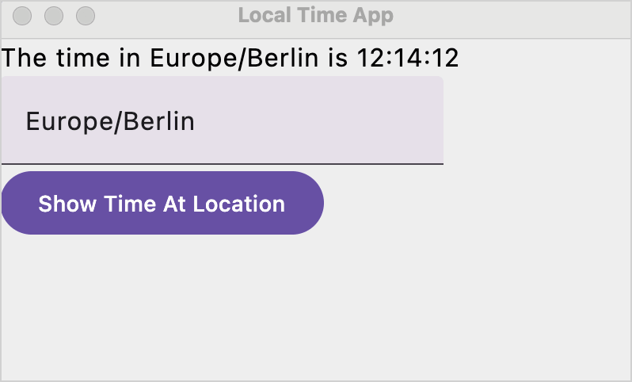

[figure not shown]

## Improve the style

The application is working, but there are issues with its appearance. The composables could be spaced better, and the time message could be rendered more prominently.

1. To address these issues, use the following version of the `App` composable:

   ```
   @Composable
   @Preview
   fun App() {
       MaterialTheme {
           var location by remember { mutableStateOf("Europe/Paris") }
           var timeAtLocation by remember { mutableStateOf("No location selected") }

           Column(
               modifier = Modifier
                   .padding(20.dp)
                   .safeContentPadding()
                   .fillMaxSize(),
           ) {
               Text(
                   timeAtLocation,
                   style = TextStyle(fontSize = 20.sp),
                   textAlign = TextAlign.Center,
                   modifier = Modifier.fillMaxWidth().align(Alignment.CenterHorizontally)
               )
               TextField(
                   value = location,
                   onValueChange = { location = it },
                   modifier = Modifier.padding(top = 10.dp)
               )
               Button(
                   onClick = { timeAtLocation = currentTimeAt(location) ?: "Invalid Location" },
                   modifier = Modifier.padding(top = 10.dp)
               ) {
                   Text("Show Time")
               }
           }
       }
   }
   ```

   - The `modifier` parameter adds padding all around the `Column`, as well as at the top of the `Button` and the `TextField`.
   - The `Text` composable fills the available horizontal space and centers its content.
   - The `style` parameter customizes the appearance of the `Text`.
2. Follow the IDE's instructions to import the missing dependencies.
3. Run the application to see how the appearance has improved:

[figure not shown]

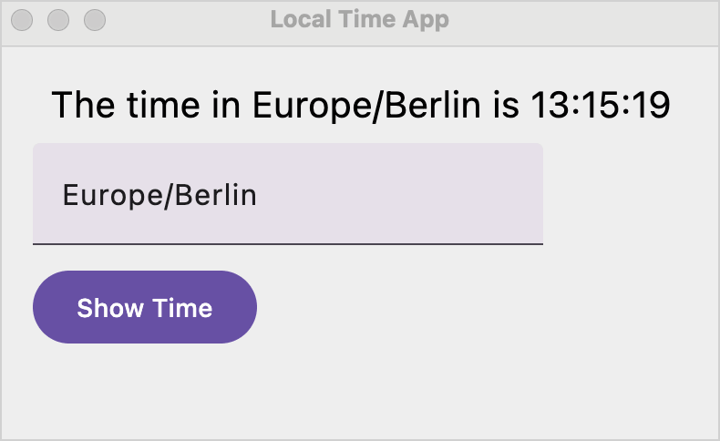

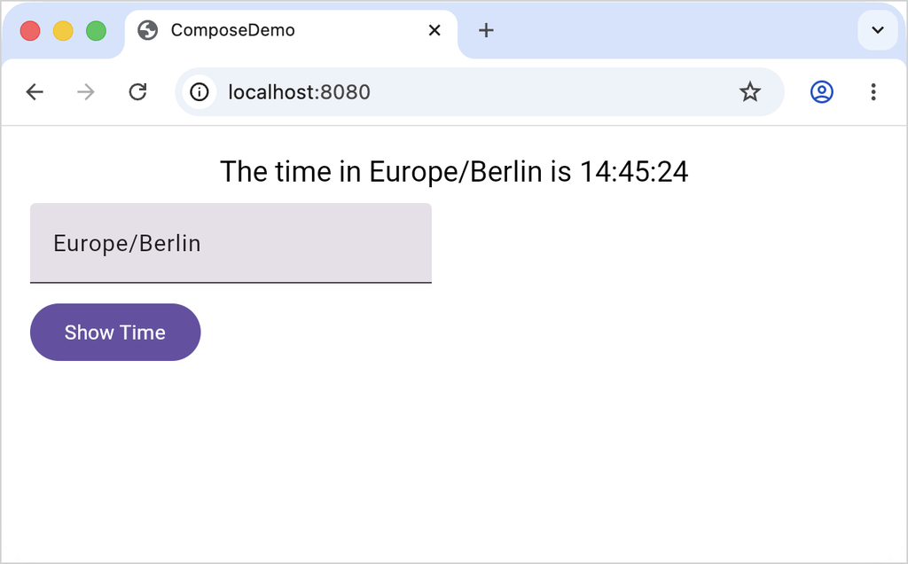

## Refactor the UI

The application works, but it's susceptible to typos. For example, if a user enters "Franse" instead of "France", the app won't be able to process that input. It would be easier for users to pick countries from a predefined list.

1. To achieve this, update the `App()` composable and the `currentTimeAt()` function, adding an auxiliary data class:

   ```
   data class Country(val name: String, val zone: TimeZone)

   fun currentTimeAt(location: String, zone: TimeZone): String {
       fun LocalTime.formatted() = "$hour:$minute:$second"

       val time = Clock.System.now()
       val localTime = time.toLocalDateTime(zone).time

       return "The time in $location is ${localTime.formatted()}"
   }

   fun countries() = listOf(
       Country("Japan", TimeZone.of("Asia/Tokyo")),
       Country("France", TimeZone.of("Europe/Paris")),
       Country("Mexico", TimeZone.of("America/Mexico_City")),
       Country("Indonesia", TimeZone.of("Asia/Jakarta")),
       Country("Egypt", TimeZone.of("Africa/Cairo")),
   )

   @Composable
   @Preview
   fun App(countries: List<Country> = countries()) {
       MaterialTheme {
           var showCountries by remember { mutableStateOf(false) }
           var timeAtLocation by remember { mutableStateOf("No location selected") }

           Column(
               modifier = Modifier
                   .padding(20.dp)
                   .safeContentPadding()
                   .fillMaxSize(),
           ) {
               Text(
                   timeAtLocation,
                   style = TextStyle(fontSize = 20.sp),
                   textAlign = TextAlign.Center,
                   modifier = Modifier.fillMaxWidth().align(Alignment.CenterHorizontally)
               )
               Row(modifier = Modifier.padding(start = 20.dp, top = 10.dp)) {
                   DropdownMenu(
                       expanded = showCountries,
                       onDismissRequest = { showCountries = false }
                   ) {
                       countries().forEach { (name, zone) ->
                           DropdownMenuItem(
                               text = {   Text(name)},
                               onClick = {
                                   timeAtLocation = currentTimeAt(name, zone)
                                   showCountries = false
                               }
                           )
                       }
                   }
               }

               Button(modifier = Modifier.padding(start = 20.dp, top = 10.dp),
                   onClick = { showCountries = !showCountries }) {
                   Text("Select Location")
               }
           }
       }
   }
   ```

   - There is a `Country` type, consisting of a name and a timezone.
   - The `currentTimeAt()` function takes a `TimeZone` as its second parameter.
   - The `App` now requires a list of countries as a parameter. The `countries()` function provides the list.
   - `DropdownMenu` has replaced the `TextField`. The value of the `showCountries` property determines the visibility of the `DropdownMenu`. There is a `DropdownMenuItem` for each country.
2. Follow the IDE's instructions to import the missing dependencies. When importing `Row()`, pick the `@Composable` version.
3. Run the application to see the redesigned version:

[figure not shown]

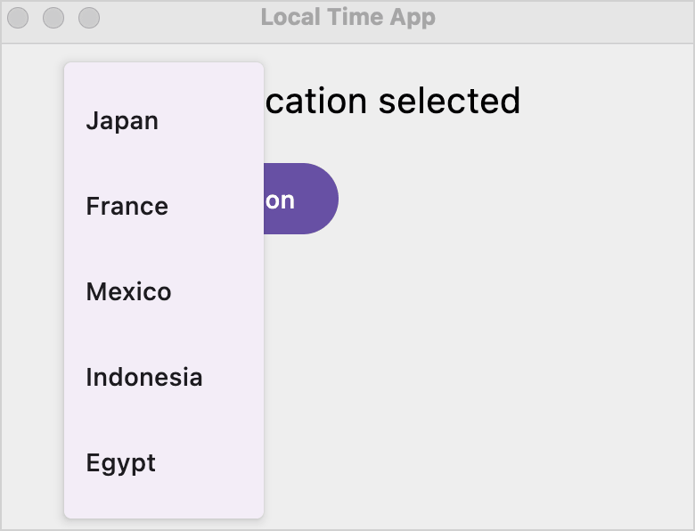

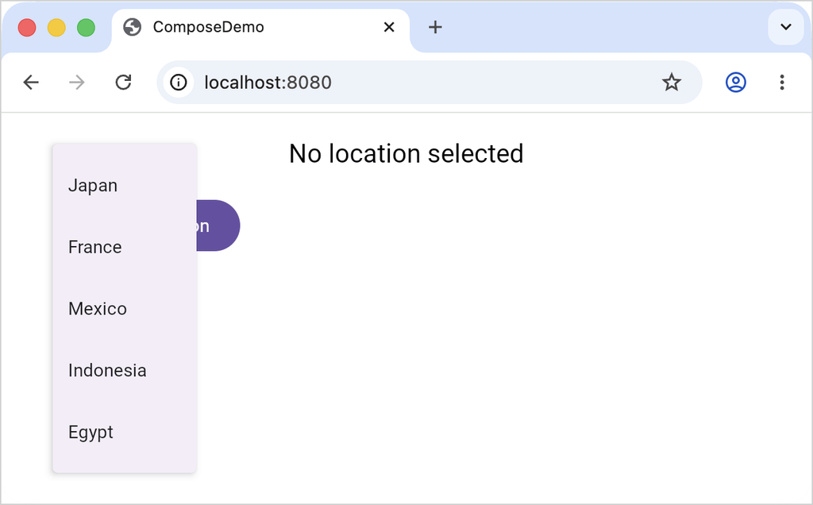

## Introduce images

The list of country names works, but it's not a great user experience. You can improve the list by adding images of national flags next to country names.

Compose Multiplatform provides a library for accessing resources through common code across all platforms. The Kotlin Multiplatform wizard has already added and configured this library, so you can start loading resources right away.

To support images in your project, you'll need to download image files, store them in the correct directory, and add code to load and display them:

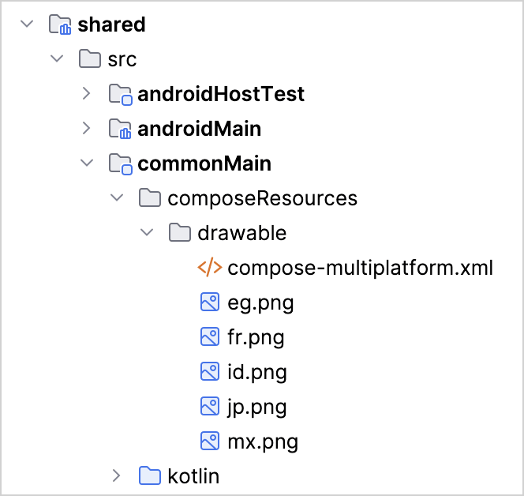

[figure not shown]

[figure not shown]

[figure not shown]

## What's next

We encourage you to explore multiplatform development further and try out more projects:

- Make your Android app cross-platform
- Create a multiplatform app using Ktor and SQLDelight
- Share business logic between iOS and Android while keeping the UI native
- Create a Compose Multiplatform app with Kotlin/Wasm
- See the curated list of sample projects

Join the community:

- Compose Multiplatform GitHub: star [the repository](https://github.com/JetBrains/compose-multiplatform) and contribute
- Kotlin Slack: Get an [invitation](https://surveys.jetbrains.com/s3/kotlin-slack-sign-up) and join the [#multiplatform](https://kotlinlang.slack.com/archives/C3PQML5NU) channel
- Stack Overflow: Subscribe to the ["kotlin-multiplatform" tag](https://stackoverflow.com/questions/tagged/kotlin-multiplatform)
- Kotlin YouTube channel: Subscribe and watch videos about [Kotlin Multiplatform](https://www.youtube.com/playlist?list=PLlFc5cFwUnmy_oVc9YQzjasSNoAk4hk_C)

10 June 2026